# Zastosowanie metod ekonometrycznych na danych panelowych

Jakub Sornat, Maciej Tajs

2025-01-23

# Wstęp

Celem niniejszej pracy jest przeprowadzenie analizy danych panelowych w celu oszacowania zależności między zmiennymi objaśniającymi a zmienną objaśnianą, z uwzględnieniem efektów czasowych oraz indywidualnych poprzez estymację modeli ekonometrycznych oraz ich interpretację. Praca będzie składała się z następujących elementów:

1. **Opis danych**: W pierwszej części pracy przedstawione zostaną dane użyte w analizie, w tym zmienne, ich jednostki miary, oraz zakres czasowy. Zostanie również wskazana zmienna objaśniana oraz omówienie oczekiwanych zależności między zmiennymi.
2. **Estymacja modeli ekonometrycznych**: W tej części pracy zostaną oszacowane modele ekonometryczne na podstawie danych panelowych, uwzględniając zarówno efekty czasowe, jak i indywidualne. Zostaną porównane różne modele (np. efekty stałe vs efekty losowe), a wybór najlepszego modelu będzie uzasadniony za pomocą odpowiednich testów i procedur estymacyjnych.
3. **Diagnostyka modelu**: Zostaną przeprowadzone testy diagnostyczne w celu oceny jakości oszacowanych modeli, takie jak testy heteroskedastyczności, autokorelacji czy endogeniczności zmiennych objaśniających. W przypadku wystąpienia problemów diagnostycznych, podjęte zostaną próby ich rozwiązania lub omówienie wpływu tych problemów na interpretację wyników.
4. **Interpretacja wyników**: W tej sekcji przedstawione zostaną wyniki oszacowanych modeli oraz ich interpretacja. Zostanie szczegółowo omówione, jak poszczególne zmienne objaśniające wpływają na zmienną objaśnianą, oraz jakie są efekty czasowe i indywidualne w badanym modelu.

## Zmienne użyte w pracy

Badanie dotyczy 16 województw Polski w okresie od 2013 roku do 2022 roku. Oznacza to, że wykorzystane dane panelowe będą postaci 16 jednostek przekroju w 10 okresach. Zbiór danych został utworzony na podstawie danych zawartych w Banku Danych Lokalnych Głównego Urzędu Statystycznego (BDL GUS). Początkowo wstępny zbiór danych zawiera 13 zmiennych objaśniających oraz 1 zmienną objaśnianą. Poniżej opisano zbiór danych:

### Zmienna endogeniczna (objaśniana):

- **malzenstwa_wskaznik** – Stosunek liczby małżeństw zawartych w danym roku do 10 tys. ludności

### Zmienne egzogeniczne (objaśniające):

- **saldo_migracji** – wskaźnik salda migracji w danym województwie na 10 tys. ludności
- **zywnosc** – wskaźnik cen dla żywności i napoi bezalkoholowych
- **rozwody** – wskaźnik rozwodów (nie wliczając separacji) ogółem na 10 tys. ludności
- **urodzenia_zywe** – wskaźnik urodzeń żywych na 10 tys. ludności
- **bezrobocie** – stopa bezrobocia
- **cena_metr_kw** – kwota za 1 m² mieszkania
- **przedszkole** – liczba przedszkoli na 10 tys. ludności
- **wynagrodzenie** – przeciętne miesięczne wynagrodzenie brutto
- **mieszkania_oddane** – mieszkania oddane do użytkowania na 1000 ludności
- **kwota_swiad_rodz** – kwoty świadczeń rodzinnych wypłaconych w roku przypadająca na 1000 mieszkańców
- **urodzenia_pozamalzenskie** – wskaźnik urodzeń żywych pozamałżeńskich na 1000 ludności
- **absolwenci_na_10000** – liczba absolwentów, którzy ukończyli studia w danym roku w przeliczeniu na 10 tys. ludności
- **srednia_cena_mieszk** – średnia cena mieszkań w danym roku w danym województwie

# Analiza danych

## Import niezbędnych bibliotek

W celu przeprowadzenia analizy danych oraz oszacowania modeli ekonometrycznych, niezbędne okazały się biblioteki w języku R, które zapewniają dostęp do funkcji ułatwiających przetwarzanie danych, estymację modeli oraz wizualizację wyników.

```r
library(readxl)
library(psych)
library(corrplot)
library(dplyr)
library(DT)
library(ggplot2)
library(reshape2)
library(tidyr)
library(gridExtra)
library(plm)
library(glmulti)
library(lmtest)
library(prais)
```

## Budowa przydatnych funkcji

Do badania przydate okazały się również funckję które na wstępnym etapie opracowano samodzielenie.

```r
coefficient_of_variation <- function(x) {
  if (mean(x, na.rm = TRUE) == 0) {
    return("NA%") # Unikamy dzielenia przez zero
  }
  cv <- (sd(x, na.rm = TRUE) / mean(x, na.rm = TRUE)) * 100
  cv_rounded <- round(cv, 2) # Zaokrąglanie do dwóch miejsc
  return(cv_rounded) # Dodanie znaku %
}
```

## Prezentacja danych

Tabela poniżej przedstawia dane użete w badaniu.

```r
data <- as.data.frame(read_excel("Projekt_EDP_dane.xlsx"))

# Wyświetlenie tabeli interaktywnej z przewijaniem
datatable(data, options = list(pageLength = 10, scrollX = TRUE, scrollY = 400))
```

|  | rok | wojewodztwo | woj_nr | malzenstwa_wskaznik | saldo_migracji | zywnosc | rozwody | urodzenia_zywe | bezrobocie | cena_metr_kw | przedszkole | wynagrodzenie | mieszkania_oddane | kwota_swiad_rodz | urodzenia_pozamalzenskie | absolwenci_na_10000 | srednia_cena_mieszk |
| --- | --- | --- | --- | --- | --- | --- | --- | --- | --- | --- | --- | --- | --- | --- | --- | --- | --- |
| 1 | 2013 | DOLNOŚLĄSKIE | 1 | 4.43 | 6.927835052 | 24.6 | 20.41 | 88.6 | 5.276907216 | 4309 | 2.216494845 | 3690 | 5.7 | 1500.1 | 33.15 | 63.99 | 238195 |
| 2 | 2013 | KUJAWSKO-POMORSKIE | 2 | 4.69 | -5.916198341 | 26 | 20.08 | 94.8 | 7.175182552 | 3204 | 3.082348893 | 3312 | 3.2 | 2225.47 | 31.24 | 43.96 | 166592 |
| 3 | 2013 | LUBELSKIE | 3 | 4.81 | -25.44349883 | 26.9 | 19.15 | 91.4 | 6.216728892 | 3835 | 2.991443081 | 3159 | 3.2 | 2291.26 | 18.06 | 57.14 | 199451 |
| 4 | 2013 | LUBUSKIE | 4 | 4.64 | -15.04694215 | 26.9 | 19.19 | 95.3 | 5.854797498 | 2504 | 6.314429205 | 2975 | 3.1 | 2330.99 | 39.85 | 19.33 | 129746 |
| 5 | 2013 | ŁÓDZKIE | 5 | 4.34 | -12.39907843 | 23.7 | 17.58 | 89 | 6.033448862 | 3385 | 2.566561484 | 3341 | 2.4 | 1826.66 | 27.01 | 46.89 | 188838 |
| 6 | 2013 | MAŁOPOLSKIE | 6 | 4.94 | 30.90835511 | 25.7 | 11.87 | 102.2 | 4.893024418 | 5658 | 1.919311547 | 3431 | 4.6 | 2003.49 | 17.2 | 71.2 | 295029 |
| 7 | 2013 | MAZOWIECKIE | 7 | 4.54 | 12.89111578 | 21.6 | 17.13 | 104.4 | 5.326396882 | 5988 | 1.213126594 | 4778 | 5.5 | 1591.94 | 26.14 | 69.07 | 359742 |
| 8 | 2013 | OPOLSKIE | 8 | 4.72 | 8.193783477 | 24 | 16.23 | 81.7 | 5.140877322 | 2674 | 6.421616455 | 3404 | 1.7 | 1452.49 | 23.17 | 46.03 | 145544 |
| 9 | 2013 | PODKARPACKIE | 9 | 5 | -26.41725646 | 27.9 | 10.95 | 95.7 | 7.242601994 | 3325 | 3.02917874 | 3010 | 2.9 | 2512.01 | 14.49 | 38.9 | 171379 |
| 10 | 2013 | PODLASKIE | 10 | 4.74 | -18.00882031 | 28.7 | 16.71 | 88.8 | 5.932282819 | 3987 | 5.397625045 | 3043 | 3.5 | 2053.83 | 18.25 | 50.79 | 204475 |

[output cut: 150 more lines]

## Statystyki opisowe

Zdecydowano się na oszacowanie statystyk opisowych, które okazały się pomocne we wstępnej analizie danych. Miary takie jak **liczba obserwacju**, **średnia**, **mediana**, **odchylenie standardowe**, **minimum**, **maksimum**, **pierwszy**, **trzeci kwartyl**, **wartość skośności** oraz **wartość kurtozy** mogą wnieść wiele cennych informacji na temat rozkładu i charakterystyki poszczególnych zmiennych.

```r
numeric_data <- data %>%
  select(-rok, -wojewodztwo, -woj_nr)

# Wyświetlenie statystyk opisowych tylko dla danych numerycznych
summary_stats <- describe(numeric_data)

# Zaokrąglanie wyników do 2 miejsc po przecinku
summary_stats_rounded <- summary_stats %>%
  mutate(across(where(is.numeric), ~ round(.x, 2)))

# Wyświetlenie tabeli w formie interaktywnej
datatable(summary_stats_rounded, options = list(pageLength = 10, scrollX = TRUE, scrollY = 400))
```

|  | vars | n | mean | sd | median | trimmed | mad | min | max | range | skew | kurtosis | se |
| --- | --- | --- | --- | --- | --- | --- | --- | --- | --- | --- | --- | --- | --- |
| malzenstwa_wskaznik | 1 | 160 | 4.63 | 0.47 | 4.73 | 4.66 | 0.39 | 3.4 | 5.42 | 2.02 | -0.68 | -0.3 | 0.04 |
| saldo_migracji | 2 | 160 | -3.36 | 12.93 | -4.57 | -3.44 | 15.56 | -33.57 | 30.91 | 64.47 | 0.11 | -0.5 | 1.02 |
| zywnosc | 3 | 160 | 26.13 | 2.4 | 26 | 26.04 | 2.52 | 20.8 | 33.3 | 12.5 | 0.38 | 0.13 | 0.19 |
| rozwody | 4 | 160 | 16.07 | 2.63 | 16.59 | 16.16 | 2.91 | 9.6 | 20.9 | 11.3 | -0.28 | -0.8 | 0.21 |
| urodzenia_zywe | 5 | 160 | 92.91 | 10.35 | 92.25 | 92.83 | 8.75 | 69 | 118.5 | 49.5 | 0.11 | -0.25 | 0.82 |
| bezrobocie | 6 | 160 | 3.47 | 1.42 | 3.23 | 3.33 | 1.39 | 1.32 | 8.01 | 6.68 | 0.82 | 0.15 | 0.11 |
| cena_metr_kw | 7 | 160 | 4551.08 | 1424.05 | 4248.5 | 4406.95 | 1306.91 | 2504 | 9651 | 7147 | 0.98 | 0.84 | 112.58 |
| przedszkole | 8 | 160 | 3.46 | 1.67 | 3.03 | 3.34 | 1.72 | 1.17 | 6.84 | 5.67 | 0.55 | -0.92 | 0.13 |
| wynagrodzenie | 9 | 160 | 4393.97 | 1039.67 | 4208.5 | 4287.26 | 1091.19 | 2836 | 8194 | 5358 | 0.89 | 0.51 | 82.19 |
| mieszkania_oddane | 10 | 160 | 4.51 | 1.69 | 4.2 | 4.36 | 1.78 | 1.7 | 9.2 | 7.5 | 0.65 | -0.29 | 0.13 |

[output cut: 4 more lines]

Na podstawie statystyk opisowych możemy wyciągnąć następujące wnioski i obserwacje dotyczące danych:

Wskaźnik **małżeństw** (średnia 4.63, odchylenie standardowe 0.47), wskazuje na dość stabilny poziom małżeństw w różnych województwach. Analizując zależności między tym wskaźnikiem a innymi zmiennymi, można zauważyć kilka istotnych trendów, które wpływają na decyzje o zawarciu małżeństwa.

**Saldo migracji** (średnia -3.36, odchylenie standardowe 12.93) wykazuje dużą zmienność, co może sugerować, że regiony z dodatnim saldem migracyjnym, czyli napływem nowych mieszkańców, mogą mieć wyższy wskaźnik małżeństw. Nowi mieszkańcy mogą bowiem przyczyniać się do większej liczby zawieranych małżeństw, szczególnie jeśli są to osoby młodsze, które często podejmują decyzje o małżeństwie. W regionach z ujemnym saldem migracyjnym, gdzie emigracja jest bardziej powszechna, wskaźnik małżeństw może być niższy, gdyż brak młodszych osób w regionie może wpłynąć na mniejszą liczbę zawieranych małżeństw.

Wysokie **bezrobocie** (średnia 3.47, odchylenie standardowe 1.42) może być czynnikiem negatywnie wpływającym na decyzję o zawarciu małżeństwa. W regionach o wyższym bezrobociu, gdzie warunki finansowe są gorsze, pary mogą odwlekać decyzję o małżeństwie, obawiając się trudności ekonomicznych. Mniejsza stabilność finansowa może prowadzić do większych trudności w podejmowaniu decyzji o założeniu rodziny.

Kolejnym czynnikiem wpływającym na wskaźnik małżeństw są **ceny nieruchomości** (średnia 4551.08 zł, odchylenie standardowe 1424.05 zł). Wysokie ceny nieruchomości w regionie mogą zniechęcać młodsze pary do zawierania małżeństw, gdyż trudności związane z zakupem mieszkania mogą sprawić, że para będzie odwlekała decyzję o założeniu rodziny. W regionach o niższych cenach nieruchomości może być łatwiej w podjęciu decyzji o małżeństwie, co może skutkować wyższym wskaźnikiem małżeństw.

Z kolei **wynagrodzenia** (średnia 4393.97 zł, odchylenie standardowe 1039.67 zł) mają wpływ na stabilność finansową par. Wyższe wynagrodzenia mogą sprzyjać zawieraniu małżeństw, ponieważ pary czują się bardziej pewne swojej sytuacji finansowej. W regionach, gdzie wynagrodzenia są wyższe, można spodziewać się wyższego wskaźnika małżeństw, ponieważ większa stabilność finansowa pozwala na bardziej swobodne podejmowanie decyzji o małżeństwie i założeniu rodziny.

Ostatnią istotną zmienną, która może wpływać na wskaźnik małżeństw, jest **liczba urodzeń żywych** (średnia 92.91, odchylenie standardowe 10.35). W regionach, gdzie wskaźnik urodzeń żywych jest wysoki, można zauważyć większą tendencję do zawierania małżeństw. Wysoki poziom urodzeń często wskazuje na większą liczbę rodzinnych decyzji podejmowanych przez młodsze pary, które decydują się na małżeństwo w celu zapewnienia stabilności dzieciom.

## Brakujące dane w zbiorze

Zbadano również wsytępowanie braków danych w zbiorze.

```r
# Liczba brakujących wartości w każdej kolumnie
missing_per_column <- colSums(is.na(data))
print(missing_per_column)
```

```
##                      rok              wojewodztwo                   woj_nr
##                        0                        0                        0
##      malzenstwa_wskaznik           saldo_migracji                  zywnosc
##                        0                        0                        0
##                  rozwody           urodzenia_zywe               bezrobocie
##                        0                        0                        0
##             cena_metr_kw              przedszkole            wynagrodzenie
##                        0                        0                        0
##        mieszkania_oddane         kwota_swiad_rodz urodzenia_pozamalzenskie
##                        0                        0                        0
##      absolwenci_na_10000      srednia_cena_mieszk
##                        0                        0
```

Wyniki pokazuja, że zestaw nie zawiera braków danych.

## Współczynnik zmienności

Obliczono współczynnik zmienności. Zdecycowane, że zmienne któtych wartość będzie niższa od 10 % będą wykluczone z badania z podobu zbyt niskiej wartości infarmacyjnej.

```r
# Obliczanie współczynnika zmienności dla każdej kolumny numerycznej
cv_per_column <- numeric_data %>%
  summarise(across(everything(), ~ coefficient_of_variation(.x))) %>%
  pivot_longer(cols = everything(), names_to = "Variable", values_to = "CV")

# Wyświetlenie wyników
print(cv_per_column)
```

```
## # A tibble: 14 × 2
##    Variable                      CV
##    <chr>                      <dbl>
##  1 malzenstwa_wskaznik        10.2
##  2 saldo_migracji           -385.
##  3 zywnosc                     9.17
##  4 rozwody                    16.4
##  5 urodzenia_zywe             11.1
##  6 bezrobocie                 40.8
##  7 cena_metr_kw               31.3
##  8 przedszkole                48.4
##  9 wynagrodzenie              23.7
## 10 mieszkania_oddane          37.6
## 11 kwota_swiad_rodz           24.4
## 12 urodzenia_pozamalzenskie   30.4
## 13 absolwenci_na_10000        35.6
## 14 srednia_cena_mieszk        33.6
```

```r
numeric_data <- numeric_data %>% select(-zywnosc)
```

## Macierz korelacji pomiędzy zmiennymi

Poniższy wykres przedstawia macierz korelacji pomiędzy zmiennymi.

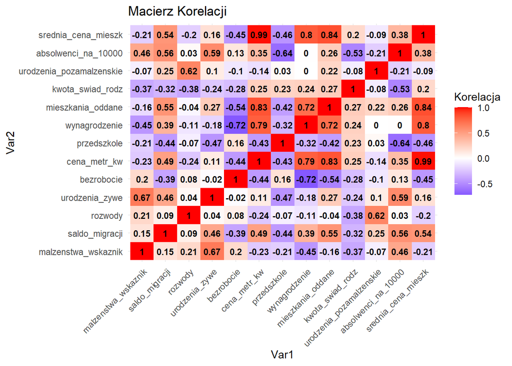

```r
# Obliczanie macierzy korelacji
cor_matrix <- cor(numeric_data, use = "complete.obs")

# Przekształcanie macierzy korelacji na format długowy (melt)
cor_matrix_melted <- melt(cor_matrix)

# Wizualizacja z ggplot2, zmniejszenie rozmiaru czcionki
ggplot(cor_matrix_melted, aes(Var1, Var2, fill = value)) +
  geom_tile() +  # Tworzenie kafelków
  scale_fill_gradient2(low = "blue", high = "red", mid = "white", midpoint = 0) +  # Kolory
  geom_text(aes(label = round(value, 2)), color = "black", size = 3, fontface = "bold") +  # Zmniejszenie czcionki
  theme_minimal() +
  theme(axis.text.x = element_text(angle = 45, hjust = 1)) +  # Obrót etykiet osi X
  labs(title = "Macierz Korelacji", fill = "Korelacja")  # Dodanie tytułu i legendy
```

Ze względu na bardzo niską korelację ze zmienną objaśnianą (malzenstwa_wskaznik) zdecydowano się na usunięcie trzech zmiennych: mieszkania_oddane, urodzenia_pozamalzenskie, saldo_migracji. Dodatkowo ze względu na wysoką zależność pomiędzy średnią ceną mieszkania a ceną średnią ceną za metr kwadratowy mieszkania usunięto cena_metr_kw.

```r
numeric_data <- numeric_data %>%
  select(-saldo_migracji, -mieszkania_oddane, -urodzenia_pozamalzenskie, -cena_metr_kw)

data <- data %>%
  select(-saldo_migracji, -mieszkania_oddane, -urodzenia_pozamalzenskie, -cena_metr_kw)
```

# Estymacja modeli

Do dalszej analizy niezbędnym jest przekształcenie danych do formatu panelowego.

```r
panel_data <- pdata.frame(data, index = c("wojewodztwo", "rok"))
```

Następnie definiujemy zmienne egzogeniczne naszego modelu

```r
# Zmienne objaśniające
zmienne <- c("rozwody", "urodzenia_zywe",
             "wynagrodzenie", "kwota_swiad_rodz", "absolwenci_na_10000",
             "srednia_cena_mieszk", "przedszkole")

# Formuła modelu
form <- as.formula(paste("malzenstwa_wskaznik ~", paste(zmienne, collapse = " + ")))
```

## Model regresji łącznej

Model regresji łącznej (ang. pooled regression model) jest jednym z podstawowych podejść w analizie danych panelowych, w którym zakłada się, że nie ma różnic między jednostkami (np. krajami, województwami, firmami) ani między okresami czasowymi, tzn. traktuje się dane jako jednorodne. Oznacza to, że wszystkie jednostki i okresy są „połączone” (ang. pooled) w jeden duży zbiór danych, a zmienne objaśniające mają jednorodny wpływ na zmienną objaśnianą. Oznacza to, że nie uwzględnia się specyficznych cech jednostek (np. województw) ani specyficznych trendów czasowych.

```r
# Model regresji łącznej
model_pool <- plm(form, data = panel_data, model = "pooling")

# Podsumowanie wyników
summary(model_pool)
```

```
## Pooling Model
##
## Call:
## plm(formula = form, data = panel_data, model = "pooling")
##
## Balanced Panel: n = 16, T = 10, N = 160
##
## Residuals:
##      Min.   1st Qu.    Median   3rd Qu.      Max.
## -0.970355 -0.118899  0.042107  0.216779  0.627339
##
## Coefficients:
##                        Estimate  Std. Error t-value  Pr(>|t|)
## (Intercept)          2.0414e+00  5.2248e-01  3.9071 0.0001402 ***
## rozwody              2.1872e-02  1.0210e-02  2.1422 0.0337707 *
## urodzenia_zywe       2.5775e-02  3.1661e-03  8.1409 1.315e-13 ***
## wynagrodzenie       -5.4980e-05  5.4048e-05 -1.0172 0.3106573
## kwota_swiad_rodz     2.6212e-06  5.9596e-05  0.0440 0.9649755
## absolwenci_na_10000  9.0130e-03  3.9271e-03  2.2951 0.0230968 *
## srednia_cena_mieszk -1.3879e-06  7.5435e-07 -1.8398 0.0677417 .
## przedszkole          2.1110e-02  2.1596e-02  0.9775 0.3298715
## ---
## Signif. codes:  0 '***' 0.001 '**' 0.01 '*' 0.05 '.' 0.1 ' ' 1
##
## Total Sum of Squares:    35.312
## Residual Sum of Squares: 13.708
## R-Squared:      0.61181
## Adj. R-Squared: 0.59393
## F-statistic: 34.2231 on 7 and 152 DF, p-value: < 2.22e-16
```

Oceniając jakość modelu regresji łącznej (Pooling Model), uwzględniamy kilka kluczowych wskaźników, które pozwalają ocenić, jak dobrze model tłumaczy zmienność zmiennej objaśnianej oraz jak istotne są poszczególne zmienne objaśniające.

*ipotezy dla testu F (efekty stałe)*

- **Hipoteza zerowa (H₀):**  
  Efekty stałe (Fixed Effects) nie są istotne, czyli wszystkie efekty indywidualne (αᵢ) są równe. W takim przypadku model **Pooled OLS** jest odpowiedni.

  $$H_0: \alpha_1 = \alpha_2 = \dots = \alpha_N = 0$$
- **Hipoteza alternatywna (H₁):**  
  Efekty stałe (Fixed Effects) są istotne, czyli przynajmniej jedno z αᵢ jest różne od 0. Oznacza to, że model **Fixed Effects** lepiej opisuje dane.

  $$H_1: \exists \, \alpha_i \neq 0$$

### Test Breuscha-Pagana

Przeprowdzono test Breuscha-Pagana w celu odpowiedzi na pytanie o zasadność stosowania modelu z efektami losowymi

*Hipotezy dla testu Breuscha-Pagana (BP)*

- **Hipoteza zerowa (H₀):**  
  Wariancja efektów losowych (σ²ᵤ) jest równa 0, co oznacza, że model **Pooled OLS** jest odpowiedni (efekty losowe nie są istotne).

  $$H_0: \sigma^2_u = 0$$
- **Hipoteza alternatywna (H₁):**  
  Wariancja efektów losowych (σ²ᵤ) jest większa od 0, co oznacza, że model **Random Effects** jest bardziej odpowiedni niż Pooled OLS.

  $$H_1: \sigma^2_u > 0$$

```r
# Test Breuscha-Pagana
bp_test <- plmtest(model_pool, type = "bp")

# Wyświetlenie wyników testu
print(bp_test)
```

```
##
##  Lagrange Multiplier Test - (Breusch-Pagan)
##
## data:  form
## chisq = 2.583, df = 1, p-value = 0.108
## alternative hypothesis: significant effects
```

## Jednokierunkowy model z efektami ustalonymi

Model regresji z efektami ustalonymi (ang. fixed effects model) zakłada się, że różnice pomiędzy jednostkami (np. krajami, województwami, firmami) są istotne i należy je uwzględnić w modelu. Model ten pozwala na kontrolowanie indywidualnych cech jednostek, które nie zmieniają się w czasie, a które mogą wpływać na zmienną objaśnianą. Dzięki temu, efekt ustalony pozwala na oddzielenie wpływu zmiennych objaśniających od wpływu specyficznych cech jednostek, które mogą stanowić istotne źródło zmienności.

```r
# Model efektów ustalonych
model_fe <- plm(form, data = panel_data, model = "within")

# Podsumowanie wyników
summary(model_fe)
```

```
## Oneway (individual) effect Within Model
##
## Call:
## plm(formula = form, data = panel_data, model = "within")
##
## Balanced Panel: n = 16, T = 10, N = 160
##
## Residuals:
##      Min.   1st Qu.    Median   3rd Qu.      Max.
## -0.696203 -0.102727  0.019792  0.153013  0.536345
##
## Coefficients:
##                        Estimate  Std. Error t-value  Pr(>|t|)
## rozwody              9.1946e-02  1.3928e-02  6.6015 8.237e-10 ***
## urodzenia_zywe       2.3538e-02  5.9133e-03  3.9805  0.000111 ***
## wynagrodzenie        2.8169e-04  1.0199e-04  2.7620  0.006534 **
## kwota_swiad_rodz    -1.4216e-04  9.8649e-05 -1.4410  0.151854
## absolwenci_na_10000  5.3952e-03  5.6945e-03  0.9474  0.345084
## srednia_cena_mieszk -4.8110e-06  1.6652e-06 -2.8891  0.004493 **
## przedszkole         -1.1411e+00  3.8346e-01 -2.9759  0.003454 **
## ---
## Signif. codes:  0 '***' 0.001 '**' 0.01 '*' 0.05 '.' 0.1 ' ' 1
##
## Total Sum of Squares:    29.834
## Residual Sum of Squares: 7.9834
## R-Squared:      0.73241
## Adj. R-Squared: 0.68943
## F-statistic: 53.5671 on 7 and 137 DF, p-value: < 2.22e-16
```

Miary dla jednokierunkowego modelu z efektami ustalonymi: 1. **Współczynnik determinacji (R-squared)**: - R-squared wynoszące **0.73241** sugeruje, że model wyjaśnia około 73,2% zmienności zmiennej zależnej, czyli wskaźnika małżeństw. Jest to stosunkowo dobra wartość, co wskazuje, że model dobrze dopasowuje się do danych, uwzględniając efekty jednostkowe.

## Dwukierunkowy model z efektami ustalonymi

Dwukierunkowy model z efektami ustalonymi (ang. **Two-way Fixed Effects Model**) to rozszerzenie modelu efektów ustalonych, który pozwala na uwzględnienie dwóch typów efektów stałych w analizie panelowej: efektów jednostkowych oraz efektów czasowych. Model dwukierunkowy zakłada, że każda jednostka może mieć swój specyficzny efekt, który pozostaje stały w czasie, a także każdy okres może mieć efekt, który jest wspólny dla wszystkich jednostek. Model uwzględnia te dwa typy efektów poprzez usunięcie zarówno efektów jednostkowych, jak i czasowych, z danych. Dzięki temu, analizując wpływ zmiennych objaśniających na zmienną zależną, można wyeliminować zarówno indywidualne cechy jednostek, jak i zmiany, które są wspólne dla wszystkich jednostek w danym czasie.

```r
# Model efektów ustalonych dwukierunkowy
model_fe_tw <- plm(form, data = panel_data, model = "within", effect = "twoways")

# Podsumowanie wyników
summary(model_fe_tw)
```

```
## Twoways effects Within Model
##
## Call:
## plm(formula = form, data = panel_data, effect = "twoways", model = "within")
##
## Balanced Panel: n = 16, T = 10, N = 160
##
## Residuals:
##       Min.    1st Qu.     Median    3rd Qu.       Max.
## -0.2365538 -0.0527330 -0.0067567  0.0582836  0.2286646
##
## Coefficients:
##                        Estimate  Std. Error t-value Pr(>|t|)
## rozwody              5.6887e-03  7.4689e-03  0.7617  0.44767
## urodzenia_zywe       7.5307e-03  4.7040e-03  1.6009  0.11186
## wynagrodzenie        3.5082e-04  8.4517e-05  4.1509    6e-05 ***
## kwota_swiad_rodz    -5.7307e-05  8.7771e-05 -0.6529  0.51498
## absolwenci_na_10000  1.8460e-03  3.6913e-03  0.5001  0.61786
## srednia_cena_mieszk  3.4512e-07  8.1302e-07  0.4245  0.67192
## przedszkole         -3.5621e-01  2.0227e-01 -1.7611  0.08061 .
## ---
## Signif. codes:  0 '***' 0.001 '**' 0.01 '*' 0.05 '.' 0.1 ' ' 1
##
## Total Sum of Squares:    1.9934
## Residual Sum of Squares: 1.2652
## R-Squared:      0.36532
## Adj. R-Squared: 0.21161
## F-statistic: 10.5253 on 7 and 128 DF, p-value: 2.1006e-10
```

Wyniki modelu **Two-Way Effects Within**, zastosowanego do danych panelowych, pokazują, że spośród analizowanych zmiennych jedynie **wynagrodzenie** ma istotny wpływ na zmienną zależną, z wartością p wynoszącą 0.00006, co wskazuje na silną statystyczną istotność. Zmienna **przedszkole** wykazuje wpływ bliski istotności (p = 0.08061), sugerując, że dostępność przedszkoli może mieć negatywny wpływ na analizowaną zmienną zależną. Pozostałe zmienne, takie jak **rozwody**, **urodzenia_zywe**, **kwota_swiad_rodz**, **absolwenci_na_10000** oraz **srednia_cena_mieszk**, nie mają istotnego wpływu na wynik modelu, ponieważ ich wartości p są znacznie wyższe niż 0.05.

Model wyjaśnia około 36.5% zmienności zmiennej zależnej (R-squared = 0.36532), a dostosowane R-squared wynosi 0.21161, co oznacza, że po uwzględnieniu liczby zmiennych model wyjaśnia 21.16% zmienności. F-statystyka (10.5253) oraz jej p-value (2.1006e-10) wskazują, że model jest statystycznie istotny jako całość.

## Jednokierunkowy model z efektami losowymi

Model regresji z efektami losowymi (ang. random effects model) jest kolejnym podejściem w analizie danych panelowych, które zakłada, że różnice między jednostkami są losowe i niezależne od zmiennych objaśniających. Oznacza to, że różnice między jednostkami traktowane są jako część składnika losowego, który jest zdefiniowany przez rozkład probabilistyczny.

W przeciwieństwie do modelu z efektami ustalonymi, model z efektami losowymi nie zakłada, że różnice między jednostkami są związane z ich indywidualnymi cechami, ale raczej traktuje je jako losowy składnik w procesie generowania danych. W związku z tym model z efektami losowymi jest bardziej odpowiedni w przypadku, gdy jednostki są traktowane jako losowe próby z populacji, a efekty jednostkowe nie są skorelowane z zmiennymi objaśniającymi.

```r
model_re <- plm(form, data = panel_data, model = "random")
summary(model_re)
```

```
## Oneway (individual) effect Random Effect Model
##    (Swamy-Arora's transformation)
##
## Call:
## plm(formula = form, data = panel_data, model = "random")
##
## Balanced Panel: n = 16, T = 10, N = 160
##
## Effects:
##                    var  std.dev share
## idiosyncratic 0.058273 0.241398 0.912
## individual    0.005598 0.074818 0.088
## theta: 0.2858
##
## Residuals:
##      Min.   1st Qu.    Median   3rd Qu.      Max.
## -0.851472 -0.109717  0.047061  0.188746  0.657015
##
## Coefficients:
##                        Estimate  Std. Error z-value  Pr(>|z|)
## (Intercept)          1.5569e+00  5.7424e-01  2.7112 0.0067039 **
## rozwody              4.0804e-02  1.1588e-02  3.5212 0.0004296 ***
## urodzenia_zywe       2.6720e-02  3.5099e-03  7.6127 2.684e-14 ***
## wynagrodzenie       -3.3485e-05  6.1449e-05 -0.5449 0.5858057
## kwota_swiad_rodz    -1.4477e-06  6.5626e-05 -0.0221 0.9824003
## absolwenci_na_10000  8.7650e-03  4.3355e-03  2.0217 0.0432117 *
## srednia_cena_mieszk -1.4034e-06  8.5720e-07 -1.6372 0.1015822
## przedszkole          2.7390e-02  2.7634e-02  0.9912 0.3216093
## ---
## Signif. codes:  0 '***' 0.001 '**' 0.01 '*' 0.05 '.' 0.1 ' ' 1
##
## Total Sum of Squares:    32.628
## Residual Sum of Squares: 12.397
## R-Squared:      0.62004
## Adj. R-Squared: 0.60254
## Chisq: 248.038 on 7 DF, p-value: < 2.22e-16
```

Wyniki modelu **One-Way (individual) Effects Random Effect Model** z zastosowaniem transformacji Swamy-Arora pokazują istotność kilku zmiennych w modelu. **Rożwody** (p = 0.0004296) oraz **urodzenia_zywe** (p = 2.684e-14) mają silny, pozytywny wpływ na analizowaną zmienną zależną. Zmienne te są statystycznie istotne, co sugeruje, że większa liczba rozwodów oraz wyższy wskaźnik urodzeń żywych mają wpływ na analizowaną zmienną. **Absolwenci na 10000** (p = 0.0432117) również wykazują istotny wpływ na wynik modelu, jednak wpływ ten jest słabszy.

Pozostałe zmienne, takie jak **wynagrodzenie**, **kwota_swiad_rodz**, **srednia_cena_mieszk**, oraz **przedszkole**, nie mają statystycznie istotnego wpływu, co widać w wartościach p powyżej 0.05.

Model wyjaśnia 62% zmienności zmiennej zależnej (R-squared = 0.62004), a dostosowane R-squared wynosi 60.25%. Test Chisq (248.038) z p-wartością poniżej 2.22e-16 wskazuje na bardzo dobrą jakość dopasowania modelu.

## Dwukierunkowy model z efektami losowymi

Dwukierunkowy model z efektami losowymi (ang. Two-Way Random Effects Model) jest rozszerzeniem klasycznego modelu z efektami losowymi, w którym uwzględnia się dwie grupy efektów:

- Efekty indywidualne: Zmienność związana z jednostkami w panelu danych, na przykład z różnicami pomiędzy poszczególnymi obiektami.
- Efekty czasowe: Zmienność związana z upływem czasu, która może wpływać na wszystkie jednostki w tym samym czasie.

Model dwukierunkowy z efektami losowymi zakłada, że zarówno efekty indywidualne, jak i czasowe są losowe i niezależne od pozostałych zmiennych w modelu. W tym przypadku wykorzystywana jest transformacja Swamy-Arora, która pozwala na wyodrębnienie i oszacowanie tych efektów w panelu danych.

```r
# Model efektów ustalonych dwukierunkowy
model_fe_tw <- plm(form, data = panel_data, model = "random", effect = "twoways")

# Podsumowanie wyników
summary(model_fe_tw)
```

```
## Twoways effects Random Effect Model
##    (Swamy-Arora's transformation)
##
## Call:
## plm(formula = form, data = panel_data, effect = "twoways", model = "random")
##
## Balanced Panel: n = 16, T = 10, N = 160
##
## Effects:
##                    var  std.dev share
## idiosyncratic 0.009884 0.099419 0.128
## individual    0.010437 0.102160 0.135
## time          0.056991 0.238728 0.737
## theta: 0.7059 (id) 0.8964 (time) 0.7005 (total)
##
## Residuals:
##       Min.    1st Qu.     Median    3rd Qu.       Max.
## -0.3073854 -0.0660605 -0.0047326  0.0704136  0.3280285
##
## Coefficients:
##                        Estimate  Std. Error z-value  Pr(>|z|)
## (Intercept)          3.1389e+00  5.6482e-01  5.5574 2.738e-08 ***
## rozwody             -3.0272e-03  7.8190e-03 -0.3872   0.69864
## urodzenia_zywe       1.7537e-02  3.8542e-03  4.5502 5.359e-06 ***
## wynagrodzenie        4.3266e-05  6.2716e-05  0.6899   0.49027
## kwota_swiad_rodz    -1.0355e-04  6.2705e-05 -1.6513   0.09867 .
## absolwenci_na_10000 -1.5399e-03  2.9143e-03 -0.5284   0.59722
## srednia_cena_mieszk  1.7871e-07  6.5334e-07  0.2735   0.78444
## przedszkole          5.4368e-04  2.6700e-02  0.0204   0.98375
## ---
## Signif. codes:  0 '***' 0.001 '**' 0.01 '*' 0.05 '.' 0.1 ' ' 1
##
## Total Sum of Squares:    2.7659
## Residual Sum of Squares: 2.1609
## R-Squared:      0.21873
## Adj. R-Squared: 0.18275
## Chisq: 42.5555 on 7 DF, p-value: 4.064e-07
```

Model wyjaśnia jedynie 21.87% zmienności zmiennej zależnej (R-squared = 0.21873), a dostosowane R-squared wynosi 18.28%. Test Chisq (42.5555) z p-wartością 4.064e-07 wskazuje na ogólną istotność modelu.

## Wybór modelu

*Hipotezy dla testu Hausmana*

- **Hipoteza zerowa (H₀):**  
  Efekty losowe (Random Effects) są nieskorelowane z regresorami, co oznacza, że model **Random Effects** jest odpowiedni.

  $$H_0: \text{Efekty losowe są nieskorelowane zmienna objaśniająca}$$
- **Hipoteza alternatywna (H₁):**  
  Efekty losowe (Random Effects) są skorelowane z regresorami, co oznacza, że model **Fixed Effects** jest bardziej odpowiedni.

  $$H_1: \text{Efekty losowe są skorelowane zmienna objaśniająca}$$

```r
# Wykonaj test Hausmana
hausman_test <- phtest(model_fe, model_re)

hausman_test
```

```
##
##  Hausman Test
##
## data:  form
## chisq = 107.13, df = 7, p-value < 2.2e-16
## alternative hypothesis: one model is inconsistent
```

Ponieważ wartość p jest bliska 0, odrzucono hipotezę zerową, która mówi, że modele są zgodne. To sugeruje, że model efektów stałych (FE) jest bardziej odpowiedni niż model efektów losowych (RE) w tym przypadku.

## Budowa ostatecznego modelu

Modelem finalnym będzie jednokierunkowy model FE. W celu wybrania zmiennych objaśniających zostanie zastosowana metoda krokowa. Pierwszym krokiem będzie usunięcie zmiennej absolwenci_na_10000, której p-value wynosiło 0.345

```r
variables_step_1  <- c("rozwody", "urodzenia_zywe",
             "wynagrodzenie", "kwota_swiad_rodz",
             "srednia_cena_mieszk", "przedszkole")
form_step_1 <- as.formula(paste("malzenstwa_wskaznik ~", paste(variables_step_1, collapse = " + ")))
model_fe_step_1 <- plm(form_step_1, data = panel_data, model = "within")
summary(model_fe_step_1)
```

```
## Oneway (individual) effect Within Model
##
## Call:
## plm(formula = form_step_1, data = panel_data, model = "within")
##
## Balanced Panel: n = 16, T = 10, N = 160
##
## Residuals:
##      Min.   1st Qu.    Median   3rd Qu.      Max.
## -0.714305 -0.089095  0.023476  0.141983  0.533163
##
## Coefficients:
##                        Estimate  Std. Error t-value  Pr(>|t|)
## rozwody              9.4568e-02  1.3645e-02  6.9304 1.469e-10 ***
## urodzenia_zywe       2.2371e-02  5.7814e-03  3.8694 0.0001676 ***
## wynagrodzenie        2.4789e-04  9.5511e-05  2.5954 0.0104693 *
## kwota_swiad_rodz    -1.4683e-04  9.8489e-05 -1.4908 0.1382934
## srednia_cena_mieszk -4.8373e-06  1.6644e-06 -2.9063 0.0042614 **
## przedszkole         -1.1537e+00  3.8309e-01 -3.0117 0.0030911 **
## ---
## Signif. codes:  0 '***' 0.001 '**' 0.01 '*' 0.05 '.' 0.1 ' ' 1
##
## Total Sum of Squares:    29.834
## Residual Sum of Squares: 8.0357
## R-Squared:      0.73065
## Adj. R-Squared: 0.68967
## F-statistic: 62.3916 on 6 and 138 DF, p-value: < 2.22e-16
```

```r
panel_data <- within(panel_data, rm(absolwenci_na_10000))
```

W drugim kroku usunięta zostanie zmienna objaśniająca kwota_swiad_rodz

```r
variables_step_2  <- c("rozwody", "urodzenia_zywe",
             "wynagrodzenie",
             "srednia_cena_mieszk", "przedszkole")
form_step_2 <- as.formula(paste("malzenstwa_wskaznik ~", paste(variables_step_2, collapse = " + ")))
model_fe_step_2 <- plm(form_step_2, data = panel_data, model = "within")
summary(model_fe_step_2)
```

```
## Oneway (individual) effect Within Model
##
## Call:
## plm(formula = form_step_2, data = panel_data, model = "within")
##
## Balanced Panel: n = 16, T = 10, N = 160
##
## Residuals:
##      Min.   1st Qu.    Median   3rd Qu.      Max.
## -0.714546 -0.102878  0.025066  0.144812  0.534800
##
## Coefficients:
##                        Estimate  Std. Error t-value  Pr(>|t|)
## rozwody              9.8853e-02  1.3398e-02  7.3784 1.324e-11 ***
## urodzenia_zywe       1.8629e-02  5.2311e-03  3.5613 0.0005059 ***
## wynagrodzenie        1.7732e-04  8.3320e-05  2.1282 0.0350838 *
## srednia_cena_mieszk -4.9019e-06  1.6711e-06 -2.9333 0.0039236 **
## przedszkole         -1.3566e+00  3.5967e-01 -3.7718 0.0002390 ***
## ---
## Signif. codes:  0 '***' 0.001 '**' 0.01 '*' 0.05 '.' 0.1 ' ' 1
##
## Total Sum of Squares:    29.834
## Residual Sum of Squares: 8.1651
## R-Squared:      0.72631
## Adj. R-Squared: 0.68694
## F-statistic: 73.7766 on 5 and 139 DF, p-value: < 2.22e-16
```

```r
final_form = form_step_2
final_model = model_fe_step_2
panel_data <- within(panel_data, rm(kwota_swiad_rodz))
```

Finalny model zawiera 5 zmiennych objaśniających:

- **rozwody**
- **urodzenia_zywe**
- **wynagrodzenie**
- **srednia_cena_mieszk**
- **przedszkole**

# Weryfikacja modelu

**Hipotezy dla testu Baltagi-Li:**

- **Hipoteza zerowa (H₀):**  
  $\rho = 0$  
  (Brak autokorelacji)
- **Hipoteza alternatywna (H₁):**  
  $\rho \neq 0$  
  (Autokorelacja występuje)

```r
pbg_test <- pbgtest(final_model)
print(pbg_test)
```

```
##
##  Breusch-Godfrey/Wooldridge test for serial correlation in panel models
##
## data:  form_step_2
## chisq = 70.265, df = 10, p-value = 3.941e-11
## alternative hypothesis: serial correlation in idiosyncratic errors
```

Bardzo małe p-value wskazuje na występowanie autokorelacji czynnika losowego. Zostanie zastosowane przekształcenie Prais Winstein

```r
prais_transformation <- prais_winsten(final_form, data = panel_data, index = "rok", panelwise = TRUE)
```

```
## Iteration 0: rho = 0
## Iteration 1: rho = 0.5996
## Iteration 2: rho = 0.7316
## Iteration 3: rho = 0.7538
## Iteration 4: rho = 0.7574
## Iteration 5: rho = 0.758
## Iteration 6: rho = 0.758
## Iteration 7: rho = 0.7581
## Iteration 8: rho = 0.7581
## Iteration 9: rho = 0.7581
```

```r
summary(prais_transformation)
```

```
##
## Call:
## prais_winsten(formula = final_form, data = panel_data, index = "rok",
##     panelwise = TRUE)
##
## Residuals:
##      Min       1Q   Median       3Q      Max
## -1.14806 -0.11059  0.08281  0.23315  0.53863
##
## AR(1) coefficient rho after 9 iterations: 0.7581
##
## Coefficients:
##                       Estimate Std. Error t value Pr(>|t|)
## (Intercept)          3.757e+00  3.008e-01  12.491  < 2e-16 ***
## rozwody             -8.019e-03  6.844e-03  -1.172 0.243136
## urodzenia_zywe       1.767e-02  2.693e-03   6.559 7.75e-10 ***
## wynagrodzenie       -1.271e-04  3.712e-05  -3.424 0.000792 ***
## srednia_cena_mieszk  8.422e-08  3.521e-07   0.239 0.811259
## przedszkole         -3.057e-02  1.157e-02  -2.641 0.009106 **
## ---
## Signif. codes:  0 '***' 0.001 '**' 0.01 '*' 0.05 '.' 0.1 ' ' 1
##
## Residual standard error: 0.2202 on 154 degrees of freedom
## Multiple R-squared:  0.591,  Adjusted R-squared:  0.5777
## F-statistic:  44.5 on 5 and 154 DF,  p-value: < 2.2e-16
##
## Durbin-Watson statistic (original): 0.7956
## Durbin-Watson statistic (transformed): 2.419
```

Następnie zbadana zostanie normalność rozkładu reszt za pomocą testu Shapiro-Wilka.

### Test Shapiro-Wilka

**Hipotezy dla testu Shapiro-Wilka**

- **Hipoteza zerowa (H₀):**  
  $H_0: \text{Próba pochodzi z populacji o rozkładzie normalnym}$
- **Hipoteza alternatywna (H₁):**  
  $H_1: \text{Próba nie pochodzi z populacji o rozkładzie normalnym}$

```r
res <- residuals(final_model)
shapiro.test(res)
```

```
##
##  Shapiro-Wilk normality test
##
## data:  res
## W = 0.97177, p-value = 0.002317
```

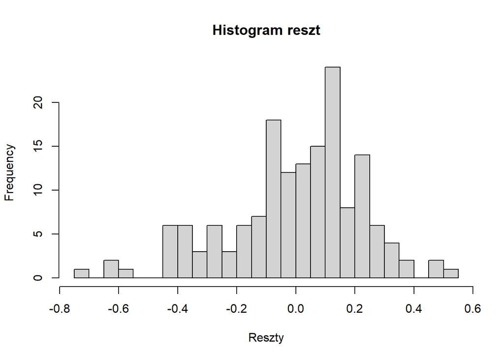

```r
hist(res, breaks = 20, main = "Histogram reszt", xlab = "Reszty")
```

P-value wynoszące **0.002317** oznacza, że należy odrzucić hipotezę zerową - reszty nie pochodzą z rozkładu normalnego.

# Ocena i interpretacja finalnego modelu

```r
summary(prais_transformation)
```

```
##
## Call:
## prais_winsten(formula = final_form, data = panel_data, index = "rok",
##     panelwise = TRUE)
##
## Residuals:
##      Min       1Q   Median       3Q      Max
## -1.14806 -0.11059  0.08281  0.23315  0.53863
##
## AR(1) coefficient rho after 9 iterations: 0.7581
##
## Coefficients:
##                       Estimate Std. Error t value Pr(>|t|)
## (Intercept)          3.757e+00  3.008e-01  12.491  < 2e-16 ***
## rozwody             -8.019e-03  6.844e-03  -1.172 0.243136
## urodzenia_zywe       1.767e-02  2.693e-03   6.559 7.75e-10 ***
## wynagrodzenie       -1.271e-04  3.712e-05  -3.424 0.000792 ***
## srednia_cena_mieszk  8.422e-08  3.521e-07   0.239 0.811259
## przedszkole         -3.057e-02  1.157e-02  -2.641 0.009106 **
## ---
## Signif. codes:  0 '***' 0.001 '**' 0.01 '*' 0.05 '.' 0.1 ' ' 1
##
## Residual standard error: 0.2202 on 154 degrees of freedom
## Multiple R-squared:  0.591,  Adjusted R-squared:  0.5777
## F-statistic:  44.5 on 5 and 154 DF,  p-value: < 2.2e-16
##
## Durbin-Watson statistic (original): 0.7956
## Durbin-Watson statistic (transformed): 2.419
```

- **R-kwadrat**: model wyjaśnia niecałe 60% procent zmienności zmiennej zależnej.